# mpl_toolkits.mplot3d.axes3d.Axes3D

**class*mpl_toolkits.mplot3d.axes3d.Axes3D(*fig*, *rect=None*, *args, *elev=30*, *azim=-60*, *roll=0*, *sharez=None*, *proj_type='persp'*, *box_aspect=None*, *computed_zorder=True*, *focal_length=None*, *shareview=None*, **kwargs)[[source]](https://github.com/matplotlib/matplotlib/blob/v3.9.2/lib/mpl_toolkits/mplot3d/axes3d.py#L40-L3734)**

Bases: `Axes`

3D Axes object.

Note

As a user, you do not instantiate Axes directly, but use Axes creation methods instead; e.g. from `pyplot` or `Figure`: `subplots`, `subplot_mosaic` or `Figure.add_axes`.

**Parameters:**

**fig**Figure**

The parent figure.

**rect**tuple (left, bottom, width, height), default: None.**

The `(left, bottom, width, height)` Axes position.

**elev**float, default: 30**

The elevation angle in degrees rotates the camera above and below the x-y plane, with a positive angle corresponding to a location above the plane.

**azim**float, default: -60**

The azimuthal angle in degrees rotates the camera about the z axis, with a positive angle corresponding to a right-handed rotation. In other words, a positive azimuth rotates the camera about the origin from its location along the +x axis towards the +y axis.

**roll**float, default: 0**

The roll angle in degrees rotates the camera about the viewing axis. A positive angle spins the camera clockwise, causing the scene to rotate counter-clockwise.

**sharez**Axes3D, optional**

Other Axes to share z-limits with. Note that it is not possible to unshare axes.

**proj_type**{'persp', 'ortho'}**

The projection type, default 'persp'.

**box_aspect**3-tuple of floats, default: None**

Changes the physical dimensions of the Axes3D, such that the ratio of the axis lengths in display units is x:y:z. If None, defaults to 4:4:3

**computed_zorder**bool, default: True**

If True, the draw order is computed based on the average position of the `Artist`s along the view direction. Set to False if you want to manually control the order in which Artists are drawn on top of each other using their *zorder* attribute. This can be used for fine-tuning if the automatic order does not produce the desired result. Note however, that a manual zorder will only be correct for a limited view angle. If the figure is rotated by the user, it will look wrong from certain angles.

**focal_length**float, default: None**

For a projection type of 'persp', the focal length of the virtual camera. Must be > 0. If None, defaults to 1. For a projection type of 'ortho', must be set to either None or infinity (numpy.inf). If None, defaults to infinity. The focal length can be computed from a desired Field Of View via the equation: focal_length = 1/tan(FOV/2)

**shareview**Axes3D, optional**

Other Axes to share view angles with. Note that it is not possible to unshare axes.

**kwargs**

Other optional keyword arguments:

| Property | Description |
| --- | --- |
| `adjustable` | {'box', 'datalim'} |
| `agg_filter` | a filter function, which takes a (m, n, 3) float array and a dpi value, and returns a (m, n, 3) array and two offsets from the bottom left corner of the image |
| `alpha` | scalar or None |
| `anchor` | (float, float) or {'C', 'SW', 'S', 'SE', 'E', 'NE', ...} |
| `animated` | bool |
| `aspect` | {'auto', 'equal', 'equalxy', 'equalxz', 'equalyz'} |
| `autoscale_on` | bool |
| `autoscalex_on` | unknown |
| `autoscaley_on` | unknown |
| `autoscalez_on` | unknown |
| `axes_locator` | Callable[[Axes, Renderer], Bbox] |
| `axisbelow` | bool or 'line' |
| `box_aspect` | 3-tuple of floats or None |
| `clip_box` | `BboxBase` or None |
| `clip_on` | bool |
| `clip_path` | Patch or (Path, Transform) or None |
| `facecolor` or fc | [color](https://matplotlib.org/stable/users/explain/colors/colors.html#colors-def) |
| `figure` | `Figure` |
| `forward_navigation_events` | bool or "auto" |
| `gid` | str |
| `in_layout` | bool |
| `label` | object |
| `mouseover` | bool |
| `navigate` | bool |
| `navigate_mode` | unknown |
| `path_effects` | list of `AbstractPathEffect` |
| `picker` | None or bool or float or callable |
| `position` | [left, bottom, width, height] or `Bbox` |
| `proj_type` | {'persp', 'ortho'} |
| `prop_cycle` | [`Cycler`](https://matplotlib.org/cycler/generated/cycler.Cycler.html#cycler.Cycler) |
| `rasterization_zorder` | float or None |
| `rasterized` | bool |
| `sketch_params` | (scale: float, length: float, randomness: float) |
| `snap` | bool or None |
| `subplotspec` | unknown |
| `title` | unknown |
| `transform` | `Transform` |
| `url` | str |
| `visible` | bool |
| `xbound` | unknown |
| `xlabel` | str |
| `xlim` or xlim3d | (left: float, right: float) |
| `xmargin` | float greater than -0.5 |
| `xscale` | unknown |
| `xticklabels` | unknown |
| `xticks` | unknown |
| `ybound` | unknown |
| `ylabel` | str |
| `ylim` or ylim3d | (bottom: float, top: float) |
| `ymargin` | float greater than -0.5 |
| `yscale` | unknown |
| `yticklabels` | unknown |
| `yticks` | unknown |
| `zbound` | unknown |
| `zlabel` | unknown |
| `zlim` or zlim3d | (bottom: float, top: float) |
| `zmargin` | float greater than -0.5 |
| `zorder` | float |
| `zscale` | unknown |
| `zticklabels` | unknown |
| `zticks` | unknown |

## Plotting

| `plot` | Plot 2D or 3D data. |
| --- | --- |
| `scatter` | Create a scatter plot. |
| `bar` | Add 2D bar(s). |
| `bar3d` | Generate a 3D barplot. |
| `plot_surface` | Create a surface plot. |
| `plot_wireframe` | Plot a 3D wireframe. |
| `plot_trisurf` | Plot a triangulated surface. |
| `clabel` | Currently not implemented for 3D Axes, and returns *None*. |
| `contour` | Create a 3D contour plot. |
| `tricontour` | Create a 3D contour plot. |
| `contourf` | Create a 3D filled contour plot. |
| `tricontourf` | Create a 3D filled contour plot. |
| `quiver` | Plot a 3D field of arrows. |
| `voxels` | Plot a set of filled voxels |
| `errorbar` | Plot lines and/or markers with errorbars around them. |
| `stem` | Create a 3D stem plot. |

## Text and annotations

| `text` | Add the text *s* to the 3D Axes at location *x*, *y*, *z* in data coordinates. |
| --- | --- |
| `text2D` | Add text to the Axes. |

## Clearing

| `clear` | Clear the Axes. |
| --- | --- |

## Appearance

| `set_axis_off` | Hide all visual components of the x- and y-axis. |
| --- | --- |
| `set_axis_on` | Do not hide all visual components of the x- and y-axis. |
| `grid` | Set / unset 3D grid. |

## Axis

### Axis limits and direction

| `get_zaxis` | Return the `ZAxis` (`Axis`) instance. |
| --- | --- |
| `get_xlim` | Return the x-axis view limits. |
| `set_xlim` | Set the 3D x-axis view limits. |
| `get_ylim` | Return the y-axis view limits. |
| `set_ylim` | Set the 3D y-axis view limits. |
| `get_zlim` | Return the 3D z-axis view limits. |
| `set_zlim` | Set the 3D z-axis view limits. |
| `get_w_lims` | Get 3D world limits. |
| `invert_xaxis` | Invert the x-axis. |
| `xaxis_inverted` | Return whether the xaxis is oriented in the "inverse" direction. |
| `invert_yaxis` | Invert the y-axis. |
| `yaxis_inverted` | Return whether the yaxis is oriented in the "inverse" direction. |
| `invert_zaxis` | Invert the z-axis. |
| `zaxis_inverted` | Return whether the zaxis is oriented in the "inverse" direction. |
| `get_xbound` | Return the lower and upper x-axis bounds, in increasing order. |
| `set_xbound` | Set the lower and upper numerical bounds of the x-axis. |
| `get_ybound` | Return the lower and upper y-axis bounds, in increasing order. |
| `set_ybound` | Set the lower and upper numerical bounds of the y-axis. |
| `get_zbound` | Return the lower and upper z-axis bounds, in increasing order. |
| `set_zbound` | Set the lower and upper numerical bounds of the z-axis. |

### Axis labels and title

| `set_zlabel` | Set zlabel. |
| --- | --- |
| `get_zlabel` | Get the z-label text string. |
| `set_title` | Set a title for the Axes. |

### Axis scales

| `set_xscale` | Set the x-axis scale. |
| --- | --- |
| `set_yscale` | Set the y-axis scale. |
| `set_zscale` | Set the z-axis scale. |
| `get_zscale` | Return the zaxis' scale (as a str). |

### Autoscaling and margins

| `get_zmargin` | Retrieve autoscaling margin of the z-axis. |
| --- | --- |
| `set_zmargin` | Set padding of Z data limits prior to autoscaling. |
| `margins` | Set or retrieve autoscaling margins. |
| `autoscale` | Convenience method for simple axis view autoscaling. |
| `autoscale_view` | Autoscale the view limits using the data limits. |
| `set_autoscalez_on` | Set whether the zaxis is autoscaled when drawing or by `Axes.autoscale_view`. |
| `get_autoscalez_on` | Return whether the zaxis is autoscaled. |
| `auto_scale_xyz` |  |

### Aspect ratio

| `set_aspect` | Set the aspect ratios. |
| --- | --- |
| `set_box_aspect` | Set the Axes box aspect. |
| `apply_aspect` | Adjust the Axes for a specified data aspect ratio. |

### Ticks

| `tick_params` | Convenience method for changing the appearance of ticks and tick labels. |
| --- | --- |
| `set_zticks` | Set the zaxis' tick locations and optionally tick labels. |
| `get_zticks` | Return the zaxis' tick locations in data coordinates. |
| `set_zticklabels` | [*Discouraged*] Set the zaxis' tick labels with list of string labels. |
| `get_zticklines` | Return the zaxis' tick lines as a list of `Line2D`s. |
| `get_zgridlines` | Return the zaxis' grid lines as a list of `Line2D`s. |
| `get_zminorticklabels` | Return the zaxis' minor tick labels, as a list of `Text`. |
| `get_zmajorticklabels` | Return the zaxis' major tick labels, as a list of `Text`. |
| `zaxis_date` | Set up axis ticks and labels to treat data along the zaxis as dates. |

## Units

| `convert_zunits` | For artists in an Axes, if the zaxis has units support, convert *z* using zaxis unit type |
| --- | --- |

## Adding artists

| `add_collection3d` | Add a 3D collection object to the plot. |
| --- | --- |

## Sharing

| `sharez` | Share the z-axis with *other*. |
| --- | --- |
| `shareview` | Share the view angles with *other*. |

## Interactive

| `can_zoom` | Return whether this Axes supports the zoom box button functionality. |
| --- | --- |
| `can_pan` | Return whether this Axes supports any pan/zoom button functionality. |
| `disable_mouse_rotation` | Disable mouse buttons for 3D rotation, panning, and zooming. |
| `mouse_init` | Set the mouse buttons for 3D rotation and zooming. |
| `drag_pan` | Called when the mouse moves during a pan operation. |
| `format_zdata` | Return *z* string formatted. |
| `format_coord` | Return a string giving the current view rotation angles, or the x, y, z coordinates of the point on the nearest axis pane underneath the mouse cursor, depending on the mouse button pressed. |

## Projection and perspective

| `view_init` | Set the elevation and azimuth of the Axes in degrees (not radians). |
| --- | --- |
| `set_proj_type` | Set the projection type. |
| `get_proj` | Create the projection matrix from the current viewing position. |
| `set_top_view` |  |

## Drawing

| `draw` | Draw the Artist (and its children) using the given renderer. |
| --- | --- |
| `get_tightbbox` | Return the tight bounding box of the Axes, including axis and their decorators (xlabel, title, etc). |

## Aliases and deprecated methods

| `set_zlim3d` | Alias for `set_zlim`. |
| --- | --- |
| `stem3D` | Create a 3D stem plot. |
| `text3D` | Add the text *s* to the 3D Axes at location *x*, *y*, *z* in data coordinates. |

## Other

| `get_axis_position` |  |
| --- | --- |
| `add_contour_set` |  |
| `add_contourf_set` |  |
| `update_datalim` | Not implemented in `Axes3D`. |

## Sample 3D data

| `axes3d.get_test_data` | Return a tuple X, Y, Z with a test data set. |
| --- | --- |

### Examples using `mpl_toolkits.mplot3d.axes3d.Axes3D`

[figure not shown]

[Animated 3D random walk](https://matplotlib.org/stable/gallery/animation/random_walk.html#sphx-glr-gallery-animation-random-walk-py)

Animated 3D random walk

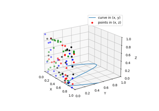

[Plot 2D data on 3D plot](https://matplotlib.org/stable/gallery/mplot3d/2dcollections3d.html#sphx-glr-gallery-mplot3d-2dcollections3d-py)

Plot 2D data on 3D plot

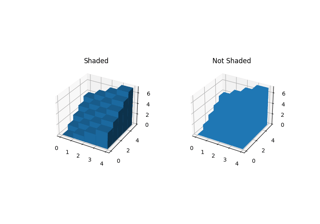

[Demo of 3D bar charts](https://matplotlib.org/stable/gallery/mplot3d/3d_bars.html#sphx-glr-gallery-mplot3d-3d-bars-py)

Demo of 3D bar charts

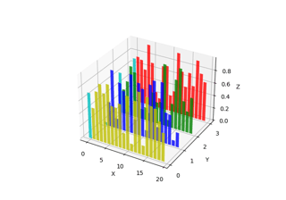

[Create 2D bar graphs in different planes](https://matplotlib.org/stable/gallery/mplot3d/bars3d.html#sphx-glr-gallery-mplot3d-bars3d-py)

Create 2D bar graphs in different planes

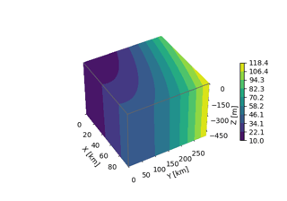

[3D box surface plot](https://matplotlib.org/stable/gallery/mplot3d/box3d.html#sphx-glr-gallery-mplot3d-box3d-py)

3D box surface plot

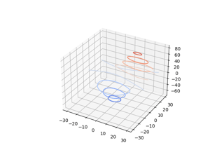

[Plot contour (level) curves in 3D](https://matplotlib.org/stable/gallery/mplot3d/contour3d.html#sphx-glr-gallery-mplot3d-contour3d-py)

Plot contour (level) curves in 3D

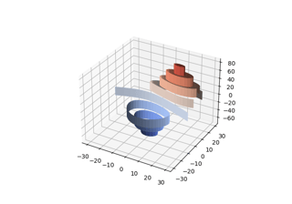

[Plot contour (level) curves in 3D using the extend3d option](https://matplotlib.org/stable/gallery/mplot3d/contour3d_2.html#sphx-glr-gallery-mplot3d-contour3d-2-py)

Plot contour (level) curves in 3D using the extend3d option

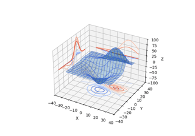

[Project contour profiles onto a graph](https://matplotlib.org/stable/gallery/mplot3d/contour3d_3.html#sphx-glr-gallery-mplot3d-contour3d-3-py)

Project contour profiles onto a graph

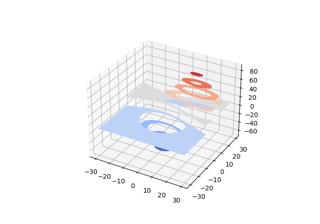

[Filled contours](https://matplotlib.org/stable/gallery/mplot3d/contourf3d.html#sphx-glr-gallery-mplot3d-contourf3d-py)

Filled contours

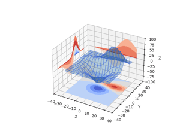

[Project filled contour onto a graph](https://matplotlib.org/stable/gallery/mplot3d/contourf3d_2.html#sphx-glr-gallery-mplot3d-contourf3d-2-py)

Project filled contour onto a graph

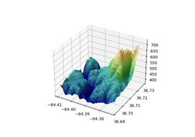

[Custom hillshading in a 3D surface plot](https://matplotlib.org/stable/gallery/mplot3d/custom_shaded_3d_surface.html#sphx-glr-gallery-mplot3d-custom-shaded-3d-surface-py)

Custom hillshading in a 3D surface plot

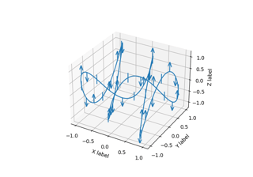

[3D errorbars](https://matplotlib.org/stable/gallery/mplot3d/errorbar3d.html#sphx-glr-gallery-mplot3d-errorbar3d-py)

3D errorbars

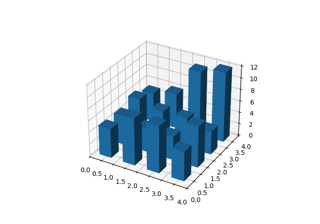

[Create 3D histogram of 2D data](https://matplotlib.org/stable/gallery/mplot3d/hist3d.html#sphx-glr-gallery-mplot3d-hist3d-py)

Create 3D histogram of 2D data

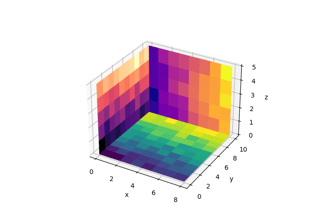

[2D images in 3D](https://matplotlib.org/stable/gallery/mplot3d/imshow3d.html#sphx-glr-gallery-mplot3d-imshow3d-py)

2D images in 3D

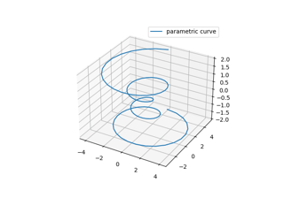

[Parametric curve](https://matplotlib.org/stable/gallery/mplot3d/lines3d.html#sphx-glr-gallery-mplot3d-lines3d-py)

Parametric curve

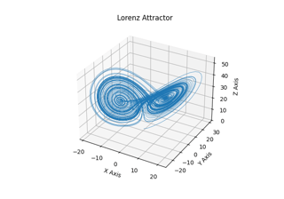

[Lorenz attractor](https://matplotlib.org/stable/gallery/mplot3d/lorenz_attractor.html#sphx-glr-gallery-mplot3d-lorenz-attractor-py)

Lorenz attractor

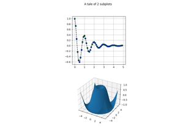

[2D and 3D Axes in same figure](https://matplotlib.org/stable/gallery/mplot3d/mixed_subplots.html#sphx-glr-gallery-mplot3d-mixed-subplots-py)

2D and 3D Axes in same figure

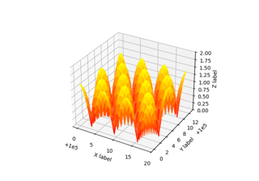

[Automatic text offsetting](https://matplotlib.org/stable/gallery/mplot3d/offset.html#sphx-glr-gallery-mplot3d-offset-py)

Automatic text offsetting

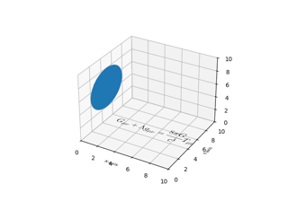

[Draw flat objects in 3D plot](https://matplotlib.org/stable/gallery/mplot3d/pathpatch3d.html#sphx-glr-gallery-mplot3d-pathpatch3d-py)

Draw flat objects in 3D plot

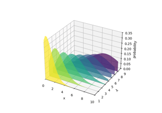

[Generate polygons to fill under 3D line graph](https://matplotlib.org/stable/gallery/mplot3d/polys3d.html#sphx-glr-gallery-mplot3d-polys3d-py)

Generate polygons to fill under 3D line graph

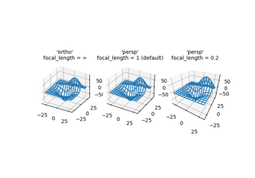

[3D plot projection types](https://matplotlib.org/stable/gallery/mplot3d/projections.html#sphx-glr-gallery-mplot3d-projections-py)

3D plot projection types

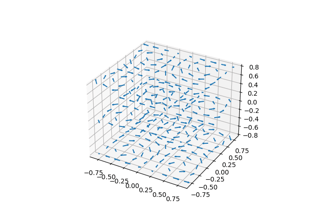

[3D quiver plot](https://matplotlib.org/stable/gallery/mplot3d/quiver3d.html#sphx-glr-gallery-mplot3d-quiver3d-py)

3D quiver plot

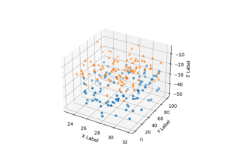

[3D scatterplot](https://matplotlib.org/stable/gallery/mplot3d/scatter3d.html#sphx-glr-gallery-mplot3d-scatter3d-py)

3D scatterplot

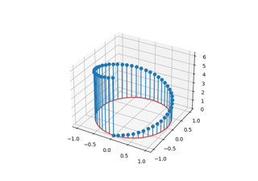

[3D stem](https://matplotlib.org/stable/gallery/mplot3d/stem3d_demo.html#sphx-glr-gallery-mplot3d-stem3d-demo-py)

3D stem

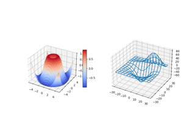

[3D plots as subplots](https://matplotlib.org/stable/gallery/mplot3d/subplot3d.html#sphx-glr-gallery-mplot3d-subplot3d-py)